# Plotting the Probability Density Function of Exponential Distribution

2019-10-28

Note that you might have to install tidyverse package if it is not already installed. You can installed it by writing `install.package(tidyverse)` in your console.

```r
library(tidyverse)
```

In our handout we worked with random variable $X$ such that $X \sim Exp(0.1)$ which indicated that $\lambda = 0.1$

Also remember that probability density function (pdf) for the Exponential Distribution is

$f(x) = \lambda e^{-\lambda x}$ for $x\geq0$

We had manually tried to plot the pdf by calculating $f(x)$ for some values of $x$. For instance

when $x = 0$, then $f(x) = 0.1e^{-0.1\times0} = 0.1$  
when $x = 1$, then $f(x) = 0.1e^{-0.1\times1} \approx 0.09$  
when $x = 2$, then $f(x) = 0.1e^{-0.1\times2} \approx 0.08$

Note that X is continous so we could calculate $f(1.5)$ or any other positive decimal number. For now we will use integers to make life easier. Also note the sample space of $X$ does not have an upper bound so plotting X by hand would be really difficult.

We now know that all probability functions (mass or density) start with the letter `d` in R. The function for exponential density is `dexp()`.

We can use this function to calculate densities as follows:

```r
dexp(x = 0, rate = 0.1)
```

```
## [1] 0.1
```

```r
dexp(x = 1, rate = 0.1)
```

```
## [1] 0.09048374
```

```r
dexp(x = 2, rate = 0.1)
```

```
## [1] 0.08187308
```

Rather than doing these one by one, we can use

```r
dexp(x = 0:10, rate = 0.1)
```

```
##  [1] 0.10000000 0.09048374 0.08187308 0.07408182 0.06703200 0.06065307
##  [7] 0.05488116 0.04965853 0.04493290 0.04065697 0.03678794
```

to calculaute $f(x)$ for $X \in \{0, 1, 2, .... 9, 10\}$.Note that this is a vector with 11 elements and the first three elements are exactly like the ones we have calculated above. We can also increase the possibilities for $x$ by changing the endpoint `dexp(x = 0:100, rate = 0.1)`. `

In order to make a ggplot we would have to have a data frame. So in the next code chunk, we will define a data frame that has all the $x$s and $f(x)$s.

```r
our_data <- data.frame(our_x = 0:100,
                       our_f_x = dexp(x = 0:100, rate = 0.1))

glimpse(our_data)
```

```
## Observations: 101
## Variables: 2
## $ our_x   <int> 0, 1, 2, 3, 4, 5, 6, 7, 8, 9, 10, 11, 12, 13, 14, 15, ...
## $ our_f_x <dbl> 0.100000000, 0.090483742, 0.081873075, 0.074081822, 0....
```

Now that we have a data frame we can use it to plot the pdf.

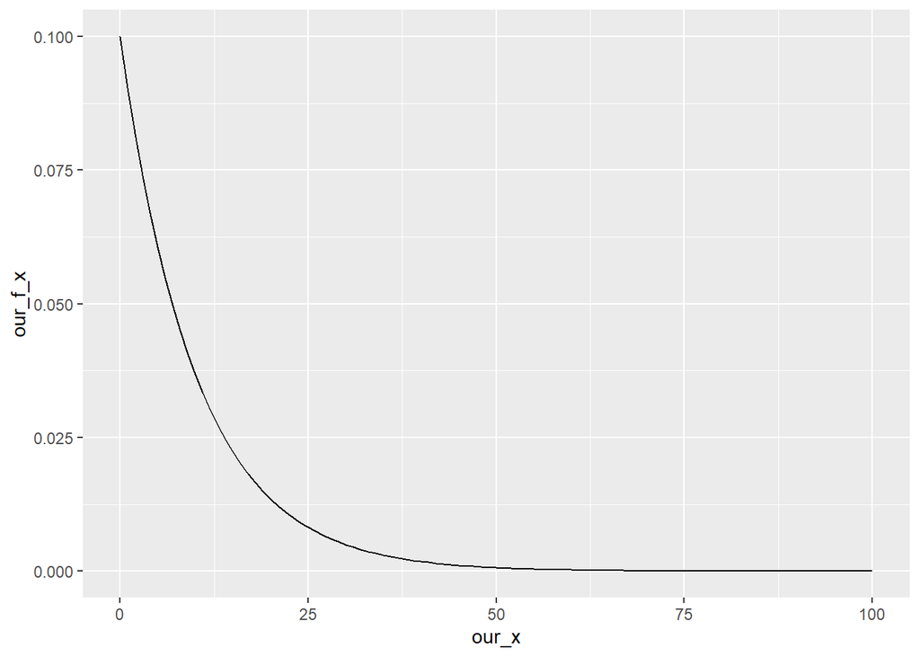

```r
our_data %>%
  ggplot(aes(x = our_x,
             y = our_f_x)) +
  geom_line()
```

And what if we wanted to include $x$s with decimal numbers? We can use the `seq()` to generate a sequence that increases at given increments.

```r
seq(from = 0, to = 2, by = 0.1)
```

```
##  [1] 0.0 0.1 0.2 0.3 0.4 0.5 0.6 0.7 0.8 0.9 1.0 1.1 1.2 1.3 1.4 1.5 1.6
## [18] 1.7 1.8 1.9 2.0
```

```r
our_data <- data.frame(our_x = seq(from = 0, to = 100, by = 0.1),
                       our_f_x = dexp(seq(from = 0, to = 100, by = 0.1),
                                      rate = 0.1))

glimpse(our_data)
```

```
## Observations: 1,001
## Variables: 2
## $ our_x   <dbl> 0.0, 0.1, 0.2, 0.3, 0.4, 0.5, 0.6, 0.7, 0.8, 0.9, 1.0,...
## $ our_f_x <dbl> 0.10000000, 0.09900498, 0.09801987, 0.09704455, 0.0960...
```

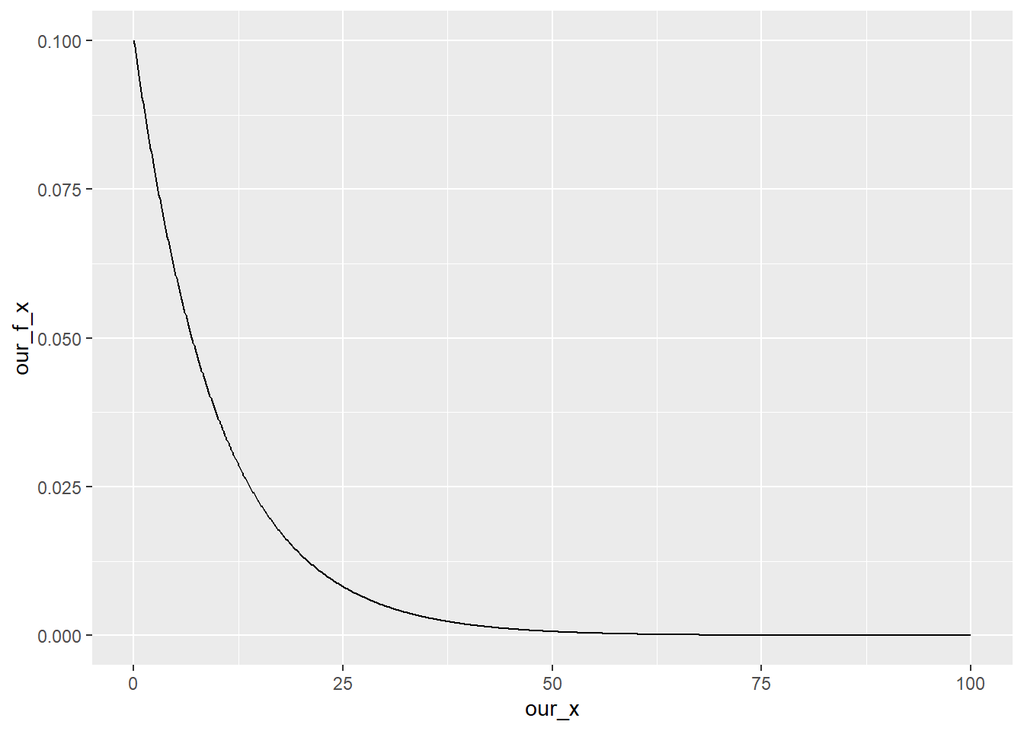

```r
our_data %>%
  ggplot(aes(x = our_x,
             y = our_f_x)) +
  geom_line()
```

Note that $x$ can go up to $\infty$  
Also note that I have used variable names such as `our_x` to distinguish it from the `x` argument in the `aes()` function. If you feel comfortable with programming you may want to use better names for your objects.

Copyright © [Dr. Mine Dogucu](https://mdogucu.ics.uci.edu). All Rights Reserved.